# EDA

### Exploratory Data Analysis

The dataset I'll explore here comes from kaggle and can be downloaded [following this link](https://www.kaggle.com/alxmamaev/flowers-recognition). It consists of flower images belonging to five flower species :

- Daisy
- Dandelion
- Rose
- Sunflower
- Tulip

First, let's import some useful libs :

```python
%load_ext autoreload
%autoreload 2
```

```python
import sys
sys.path.append("../utils") # or whatever the path to the utils directory containing the utilities script
```

```python
from bokeh.io import output_notebook
from data_utils import split_flower_data
from plot_utils import display_sample_images, plot_class_distribution, plot_image_dimensions
```

```python
output_notebook()
```

```python
%matplotlib inline
```

The original dataset is not divided into training, validation and test sets, let's do it :

```python
train_percent = 0.7  # part of the data to consider for train set
root_folder = "../../../flowers-recognition/flowers"  # directory containing subdirectory
                                                                                        # each containing images for 1 class
out_folder = "../../../flowers-recognition/split_flower"  # folder where to save the split data
classes = ['daisy', 'dandelion', 'rose', 'sunflower', 'tulip']  # class names corresponding also to subdirs on `root_folder`
```

```python
%%time
split_flower_data(root_folder, out_folder, classes, train_percent)
```

```
==========CLASS : daisy===========
*******[COPYING TRAIN IMAGES]***********
```

```
*******[COPYING VALIDATION IMAGES]***********
```

```
*******[COPYING TEST IMAGES]***********
```

```
===============================


==========CLASS : dandelion===========
*******[COPYING TRAIN IMAGES]***********
```

```
*******[COPYING VALIDATION IMAGES]***********
```

```
*******[COPYING TEST IMAGES]***********
```

```
===============================


==========CLASS : rose===========
*******[COPYING TRAIN IMAGES]***********
```

```
*******[COPYING VALIDATION IMAGES]***********
```

```
*******[COPYING TEST IMAGES]***********
```

```
===============================


==========CLASS : sunflower===========
*******[COPYING TRAIN IMAGES]***********
```

```
*******[COPYING VALIDATION IMAGES]***********
```

```
*******[COPYING TEST IMAGES]***********
```

```
===============================


==========CLASS : tulip===========
*******[COPYING TRAIN IMAGES]***********
```

```
*******[COPYING VALIDATION IMAGES]***********
```

```
*******[COPYING TEST IMAGES]***********
```

```
===============================


Wall time: 45.9 s
```

After data spliting, let's display some sample images for each class from training data :

```python
sample_path = "../../../flowers-recognition/split_flower/train/"
```

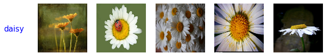

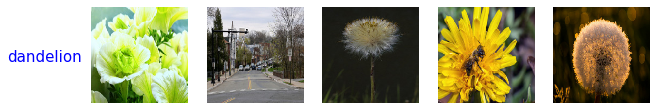

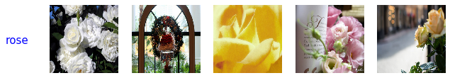

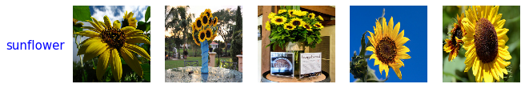

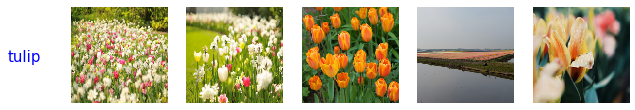

```python
display_sample_images(sample_path)
```

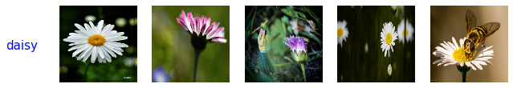

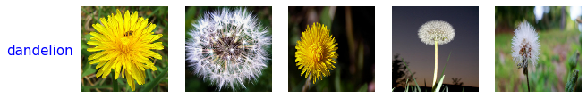

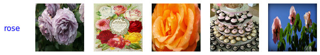

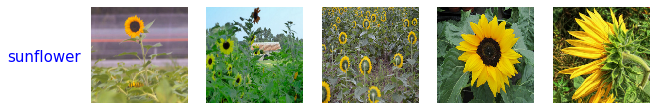

[figure not shown]

```python
display_sample_images(sample_path)
```

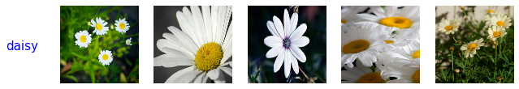

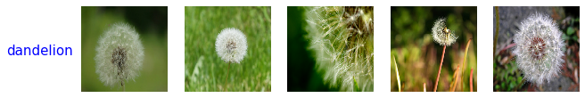

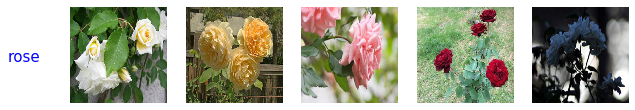

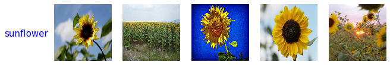

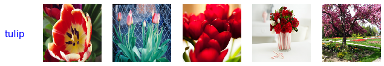

```python
display_sample_images(sample_path)
```

Some images are quite noisy, as they are not only composed of the flower picture, or sometimes the flower is not even visible. We should pay particular attention when assessing the model's performance as it may be affected by these noisy samples.

One important aspect to investigate is the distribution of classes in our dataset, as imbalanced dataset may yield poor results. Following is the distribution of our data in the train, validation and test sets :

```python
path_train = "../../../../COMPUTER_VISION/flowers-recognition/split_flower/train"
path_valid = "../../../../COMPUTER_VISION/flowers-recognition/split_flower/valid"
path_test = "../../../../COMPUTER_VISION/flowers-recognition/split_flower/test"
```

```python
plot_class_distribution(path_train, title="Train set classes distribution")
```

[interactive chart not shown]

```python
plot_class_distribution(path_valid, title="Validation set classes distribution")
```

[interactive chart not shown]

```python
plot_class_distribution(path_test, title="Test set classes distribution")
```

[interactive chart not shown]

From above plots, we can see that the dataset is fairly balanced. There are two classes -`dandelion` and `tulip`- each with a little more than 20% of the data. The other classes have proportions of around 17-18%.

Overall, we have 3028 training samples, 651 validation and 644 test ones.

When using a pretrained model for transfer learning we may be required to resize our images to match the original model input shape. In this case the choice of the images dimensions is direct.

However for our own custom models we may need some insights for choosing the right dimensions. Let's visualize the dimensions -`height` and `width`- from the training images :

```python
plot_image_dimensions(path_train)
```

[interactive chart not shown]

The mean height is around 245-260 and mean width around 320-350. We may take these values into account when resizing images with custom dimensions.